# Упражнение 8

Владимиров Андрей

12 05 2021

Необходимо построить две модели для прогноза на основе дерева решений: - *для непрерывной зависимой переменной;* - *для категориальной зависимой переменной.*

Данные и переменные указаны в таблице с вариантами.

Ядро генератора случайных чисел – номер варианта.

Задания Для каждой модели:

1. Указать настроечные параметры метода из своего варианта (например: количество узлов, количество предикторов, скорость обучения).
2. Подогнать модель на обучающей выборке (50% наблюдений). Рассчитать MSE на тестовой выборке.
3. Перестроить модель с помощью метода, указанного в варианте.
4. Сделать прогноз по модели с подобранными в п.3 параметрами на тестовой выборке, оценить его точность и построить график «прогноз-реализация».

Как сдавать: прислать на почту преподавателя ссылки: * на html-отчёт с видимыми блоками кода (блоки кода с параметром echo = T), размещённый на rpubs.com. * на код, генерирующий отчёт, в репозитории на github.com. В текст отчёта включить постановку задачи и ответы на вопросы задания.

## Вариант 8

- Метод подгонки моделей: бустинг
- Данные: *Wage{ISLR}*

```r
str(Wage)
```

```
## 'data.frame':    3000 obs. of  11 variables:
##  $ year      : int  2006 2004 2003 2003 2005 2008 2009 2008 2006 2004 ...
##  $ age       : int  18 24 45 43 50 54 44 30 41 52 ...
##  $ maritl    : Factor w/ 5 levels "1. Never Married",..: 1 1 2 2 4 2 2 1 1 2 ...
##  $ race      : Factor w/ 4 levels "1. White","2. Black",..: 1 1 1 3 1 1 4 3 2 1 ...
##  $ education : Factor w/ 5 levels "1. < HS Grad",..: 1 4 3 4 2 4 3 3 3 2 ...
##  $ region    : Factor w/ 9 levels "1. New England",..: 2 2 2 2 2 2 2 2 2 2 ...
##  $ jobclass  : Factor w/ 2 levels "1. Industrial",..: 1 2 1 2 2 2 1 2 2 2 ...
##  $ health    : Factor w/ 2 levels "1. <=Good","2. >=Very Good": 1 2 1 2 1 2 2 1 2 2 ...
##  $ health_ins: Factor w/ 2 levels "1. Yes","2. No": 2 2 1 1 1 1 1 1 1 1 ...
##  $ logwage   : num  4.32 4.26 4.88 5.04 4.32 ...
##  $ wage      : num  75 70.5 131 154.7 75 ...
```

```r
head(Wage)
```

```
##        year age           maritl     race       education             region
## 231655 2006  18 1. Never Married 1. White    1. < HS Grad 2. Middle Atlantic
## 86582  2004  24 1. Never Married 1. White 4. College Grad 2. Middle Atlantic
## 161300 2003  45       2. Married 1. White 3. Some College 2. Middle Atlantic
## 155159 2003  43       2. Married 3. Asian 4. College Grad 2. Middle Atlantic
## 11443  2005  50      4. Divorced 1. White      2. HS Grad 2. Middle Atlantic
## 376662 2008  54       2. Married 1. White 4. College Grad 2. Middle Atlantic
##              jobclass         health health_ins  logwage      wage
## 231655  1. Industrial      1. <=Good      2. No 4.318063  75.04315
## 86582  2. Information 2. >=Very Good      2. No 4.255273  70.47602
## 161300  1. Industrial      1. <=Good     1. Yes 4.875061 130.98218
## 155159 2. Information 2. >=Very Good     1. Yes 5.041393 154.68529
## 11443  2. Information      1. <=Good     1. Yes 4.318063  75.04315
## 376662 2. Information 2. >=Very Good     1. Yes 4.845098 127.11574
```

# Модель 1 (для непрерывной зависимой переменной wage)

```r
# Избавляемся от region и logwage
Wage <- Wage[, c(-6,-10) ]

# ?Wage
head(Wage)
```

```
##        year age           maritl     race       education       jobclass
## 231655 2006  18 1. Never Married 1. White    1. < HS Grad  1. Industrial
## 86582  2004  24 1. Never Married 1. White 4. College Grad 2. Information
## 161300 2003  45       2. Married 1. White 3. Some College  1. Industrial
## 155159 2003  43       2. Married 3. Asian 4. College Grad 2. Information
## 11443  2005  50      4. Divorced 1. White      2. HS Grad 2. Information
## 376662 2008  54       2. Married 1. White 4. College Grad 2. Information
##                health health_ins      wage
## 231655      1. <=Good      2. No  75.04315
## 86582  2. >=Very Good      2. No  70.47602
## 161300      1. <=Good     1. Yes 130.98218
## 155159 2. >=Very Good     1. Yes 154.68529
## 11443       1. <=Good     1. Yes  75.04315
## 376662 2. >=Very Good     1. Yes 127.11574
```

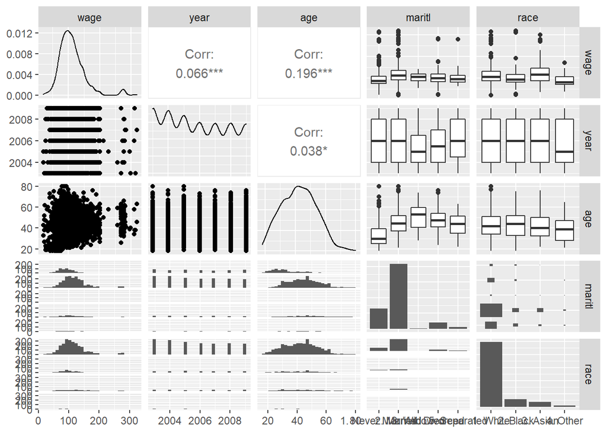

```r
# матричные графики разброса переменных
p <- ggpairs(Wage[, c(9, 1:4)])
suppressMessages(print(p))
```

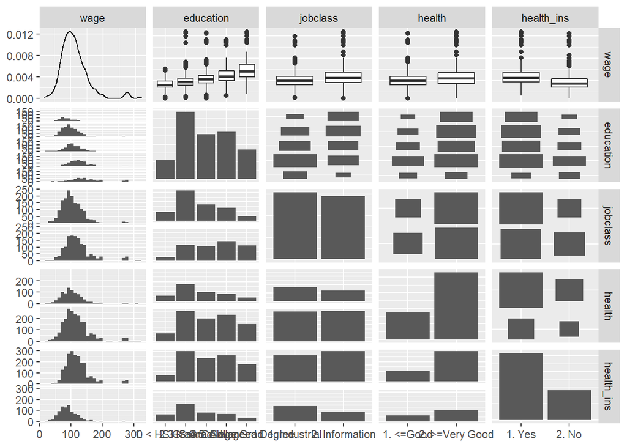

```r
p <- ggpairs(Wage[, c(9, 5:8)])
suppressMessages(print(p))
```

```r
# Обучающая выборка
set.seed(my.seed)
# Обучающая выборка - 50%
train <- sample(1:nrow(Wage), nrow(Wage)/2)
```

Построим дерево регрессии для зависимой переменной wage.

```r
# Обучаем модель
tree.wage <- tree(wage ~ ., Wage, subset = train)
summary(tree.wage)
```

```
##
## Regression tree:
## tree(formula = wage ~ ., data = Wage, subset = train)
## Variables actually used in tree construction:
## [1] "education"  "health_ins" "maritl"     "age"
## Number of terminal nodes:  7
## Residual mean deviance:  1404 = 2096000 / 1493
## Distribution of residuals:
##     Min.  1st Qu.   Median     Mean  3rd Qu.     Max.
## -121.100  -20.360   -4.849    0.000   13.860  215.400
```

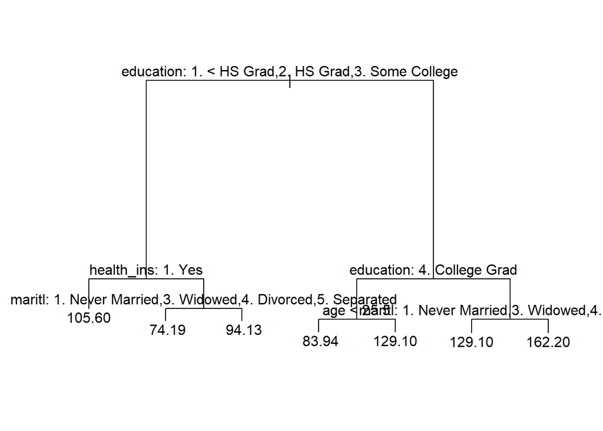

```r
# Визуализация
plot(tree.wage)
text(tree.wage, pretty = 0)
```

```r
tree.wage                    # Посмотреть всё дерево в консоли
```

```
## node), split, n, deviance, yval
##       * denotes terminal node
##
##  1) root 1500 2949000 113.20
##    2) education: 1. < HS Grad,2. HS Grad,3. Some College 944  930700  98.49
##      4) health_ins: 1. Yes 598  500600 105.60 *
##      5) health_ins: 2. No 346  347300  86.18
##       10) maritl: 1. Never Married,3. Widowed,4. Divorced,5. Separated 138   54850  74.19 *
##       11) maritl: 2. Married 208  259400  94.13 *
##    3) education: 4. College Grad,5. Advanced Degree 556 1466000 138.20
##      6) education: 4. College Grad 335  649200 126.70
##       12) age < 25.5 18   10510  83.94 *
##       13) age > 25.5 317  604000 129.10 *
##      7) education: 5. Advanced Degree 221  704400 155.70
##       14) maritl: 1. Never Married,3. Widowed,4. Divorced 43   79210 129.10 *
##       15) maritl: 2. Married,5. Separated 178  587300 162.20 *
```

```r
# Прогноз по модели
yhat <- predict(tree.wage, newdata = Wage[-train, ])
wage.test <- Wage[-train, "wage"]

# MSE на тестовой выборке
mse.test <- mean((yhat - wage.test)^2)
names(mse.test)[length(mse.test)] <- 'Wage.regr.tree.all'
mse.test
```

```
## Wage.regr.tree.all
##           1129.022
```

```r
# Точность прогноза на тестовой выборке
acc.test <- sum(abs(yhat-wage.test))/sum(wage.test)
names(acc.test)[length(acc.test)] <- 'Wage.regr.tree.all'
acc.test
```

```
## Wage.regr.tree.all
##          0.2181455
```

#Бустинг (модель 1)

Проведем бустинг с целью улучшения модели

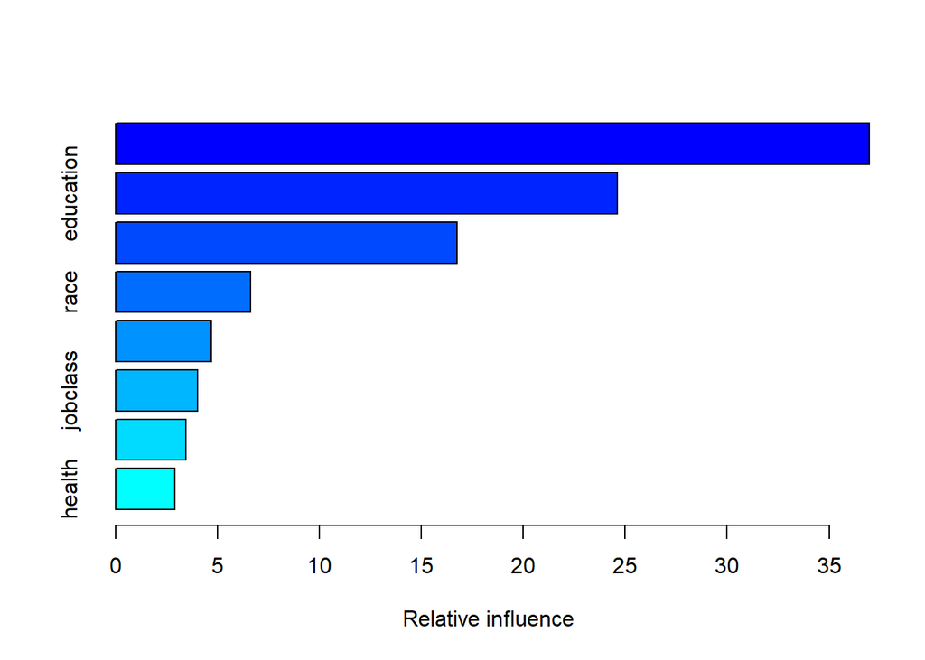

```
##                   var   rel.inf
## age               age 36.968781
## education   education 24.609666
## year             year 16.753826
## race             race  6.612620
## maritl         maritl  4.690118
## jobclass     jobclass  4.018428
## health_ins health_ins  3.446152
## health         health  2.900411
```

```r
set.seed(my.seed)
boost.wage <- gbm(wage ~ ., data = Wage[train, ], distribution = "gaussian",
                    n.trees = 5000, interaction.depth = 4)
# График и таблица относительной важности переменных
summary(boost.wage)
```

```r
# прогноз
yhat.boost <- predict(boost.wage, newdata = Wage[-train, ], n.trees = 5000)

# MSE на тестовой
mse.test <- c(mse.test, mean((yhat.boost - wage.test)^2))
names(mse.test)[length(mse.test)] <- 'Wage.boost.opt'
mse.test
```

```
## Wage.regr.tree.all     Wage.boost.opt
##           1129.022           1382.455
```

```r
# Точность прогноза на тестовой выборке
acc.test <- c(acc.test, sum(abs(yhat.boost-wage.test))/sum(wage.test))
names(acc.test)[length(acc.test)] <- 'Wage.regr.tree'
acc.test
```

```
## Wage.regr.tree.all     Wage.regr.tree
##          0.2181455          0.2470171
```

```r
# Меняем значение гиперпараметра (lambda) на 0.1 -- аргумент shrinkage
boost.wage <- gbm(wage ~ ., data = Wage[train, ], distribution = "gaussian",
                    n.trees = 5000, interaction.depth = 4,
                    shrinkage = 0.1, verbose = F)

# Прогноз
yhat.boost <- predict(boost.wage, newdata = Wage[-train, ], n.trees = 5000)

# MSE а тестовой
mse.test <- c(mse.test, mean((yhat.boost - wage.test)^2))
names(mse.test)[length(mse.test)] <- 'Wage.boost.0.1'
mse.test
```

```
## Wage.regr.tree.all     Wage.boost.opt     Wage.boost.0.1
##           1129.022           1382.455           1401.307
```

```r
# Точность прогноза на тестовой выборке
acc.test <- c(acc.test, sum(abs(yhat.boost-wage.test))/sum(wage.test))
names(acc.test)[length(acc.test)] <- 'Wage.regr.tree.0.1'
acc.test
```

```
## Wage.regr.tree.all     Wage.regr.tree Wage.regr.tree.0.1
##          0.2181455          0.2470171          0.2488221
```

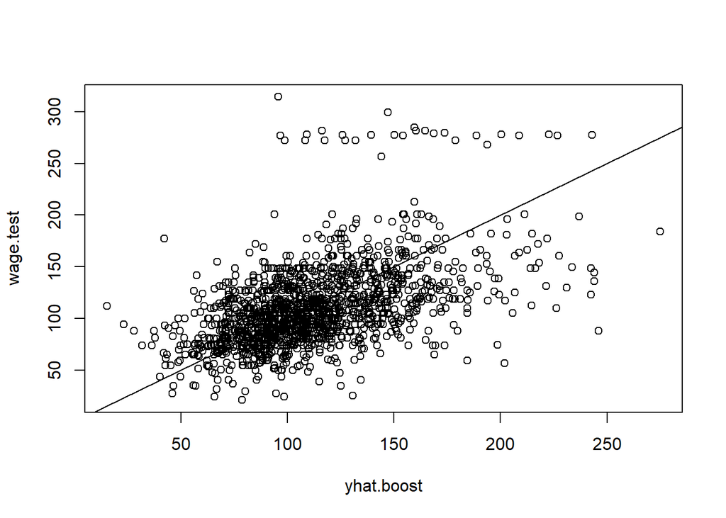

```r
# График "прогноз - реализация"
plot(yhat.boost, wage.test)
# линия идеального прогноза
abline(0, 1)
```

```r
# прогноз
yhat.boost <- predict(boost.wage, newdata = Wage[-train, ], n.trees = 5000)

# MSE на тестовой
mse.test <- c(mse.test, mean((yhat.boost - wage.test)^2))
names(mse.test)[length(mse.test)] <- 'Wage.boost.opt'
mse.test
```

```
## Wage.regr.tree.all     Wage.boost.opt     Wage.boost.0.1     Wage.boost.opt
##           1129.022           1382.455           1401.307           1401.307
```